# Binary Group Lasso

02343497

2023-04-13

```r
# load the necessary package
library(glmnet)
library(dplyr)
```

```r
library(corrplot)
library(gglasso)
library(grpreg)
library(tidyverse)
library(openxlsx)
library(omics)
library(cluster)
library(gower)
library(factoextra)
library(Rtsne)
library(clustMixType)
library(glmnet)
library(nnet)
library(grpreg)
library(clusterCons)
library(clustMixType)
library(glue)
library(caret)
# load data
data <- read.csv("imputed_baseline.csv")
```

```r
data$case<- ifelse(data$cohort.x %in% c("cohort_a", "cohort_b","cohort_c"), "1", "0")
table(data$case)
```

```
##
##   0   1
##  90 429
```

```r
# Convert the response variable to numeric
data$case <- as.numeric(data$case)
```

```r
# Denoising ----------
proteins <- c("CCL18", "IL18", "CCL5", "i.TAC", "TARC", "IL.10", "IL.16", "MIP.1a", "PAPP.A", "IL17", "TSLP", "SP.A", "CTACK", "KL.6", "MPO", "EDN", "IL.6", "TNF.A", "MIG", "CCL20", "IP.10", "IL.4", "IL.5")
X <- data[, proteins]
model = mlmer(X ~ (1|PLATE.ID), data=data, save.residuals = TRUE, save.ranks = TRUE)
```

```
## boundary (singular) fit: see help('isSingular')
## boundary (singular) fit: see help('isSingular')
## boundary (singular) fit: see help('isSingular')
## boundary (singular) fit: see help('isSingular')
## boundary (singular) fit: see help('isSingular')
```

```r
saveRDS(model$residuals, "proteins_denoised.rds")
X <- readRDS("proteins_denoised.rds")
```

```r
# Create a list of all variables
variables <- c("CCL18", "CCL5", "i.TAC", "TARC", "MIP.1a", "MIG", "CCL20", "IP.10", "CTACK",
               "IL.10", "IL.16", "IL17", "TSLP", "IL.4", "IL.5",
               "PAPP.A", "KL.6", "MPO", "EDN",
               "IL18", "SP.A", "IL.6", "TNF.A")

# Create a grouping variable based on the functional categories
group <- rep(NA, length(variables))

group[variables %in% c("CCL18", "CCL5", "i.TAC", "TARC", "MIP.1a", "MIG", "CCL20", "IP.10", "CTACK")] <- 1
group[variables %in% c("IL.10", "IL.16", "IL17", "TSLP", "IL.4", "IL.5")] <- 2
group[variables %in% c("PAPP.A", "KL.6", "MPO", "EDN")] <- 3
group[variables %in% c("IL18", "SP.A", "IL.6", "TNF.A")] <- 4

# Define the groups
groups <- group


# Assuming 'X' is your data frame containing the variables
X <- as.matrix(X[, variables])

# Define the response variable (y)
# Replace 'response' with the name of the response variable in your data frame
y <- data$case

# Set the regularization parameter
lambda <- 0.1

# Fit the binary group Lasso model
fit <- grpreg(X, y, group = groups, family = "binomial")

# Get the coefficients
coefficients <- coef(fit)
```

```r
print(coefficients)
```

[output not shown]

```r
# perform cross validation
# Generate a sequence of lambda values to search over
lambdas <- exp(seq(-4, 0, length.out = 50))

# Prepare a matrix for cross-validated errors
cv_errors <- matrix(0, nrow = length(lambdas), ncol = 5)

# Perform cross-validation
set.seed(42)
nfolds <- 5
fold_indices <- split(sample(seq_len(nrow(X)), size = nrow(X), replace = FALSE), rep(1:nfolds, length.out = nrow(X)))

for (i in seq_along(lambdas)) {
  lambda <- lambdas[i]

  for (j in 1:nfolds) {
    test_indices <- fold_indices[[j]]
    train_indices <- unlist(fold_indices[-j], use.names = FALSE)

    fit <- grpreg(X[train_indices,], y[train_indices], group = groups, family = "binomial", lambda = lambda)

    # Compute the prediction error for the current fold
    preds <- predict(fit, X[test_indices,], type = "response")
    test_error <- mean((y[test_indices] - preds)^2)
    cv_errors[i, j] <- test_error
  }
}

# Calculate the mean cross-validated error for each lambda
mean_cv_errors <- colMeans(cv_errors)

# Get the best lambda
best_lambda <- lambdas[which.min(mean_cv_errors)]
cat("Best lambda:", best_lambda)
```

```
## Best lambda: 0.02339806
```

```r
# Fit the binary group Lasso model with the best lambda value
fit_best <- grpreg(X, y, group = groups, family = "binomial", lambda = best_lambda)

# Get the coefficients with the best lambda value
coefficients_best <- coef(fit_best)

# Print the coefficients with the best lambda value
print(coefficients_best)
```

```
##  (Intercept)        CCL18         CCL5        i.TAC         TARC       MIP.1a
##  1.715919812  0.555273596  0.175782191 -0.034988312  0.001540116 -0.022515887
##          MIG        CCL20        IP.10        CTACK        IL.10        IL.16
##  0.283722001 -0.011055837 -0.341621886 -0.096409594  0.000000000  0.000000000
##         IL17         TSLP         IL.4         IL.5       PAPP.A         KL.6
##  0.000000000  0.000000000  0.000000000  0.000000000  0.086632373 -0.022724112
##          MPO          EDN         IL18         SP.A         IL.6        TNF.A
## -0.056986821  0.582420237 -0.089975913  0.605660512  0.130059215 -0.064454832
```

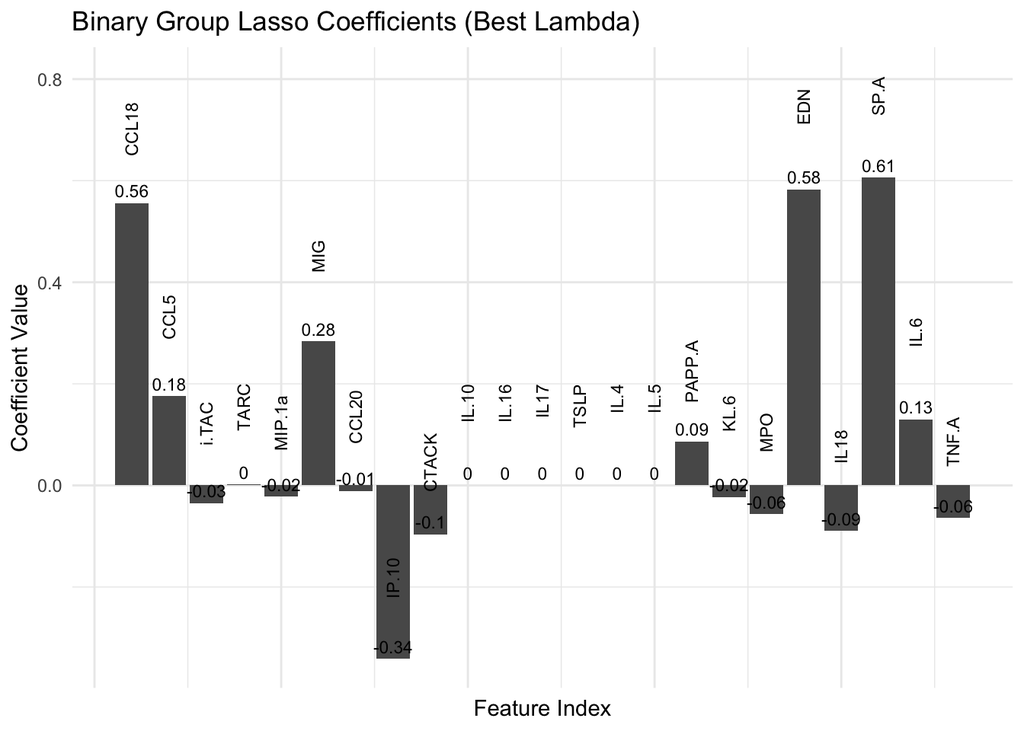

```r
# Remove the intercept
coefficients_best <- coefficients_best [-1]


# Create a data frame with feature index, feature names, and coefficients
coef_df <- data.frame(FeatureIndex = 1:length(coefficients_best),
                      FeatureName = variables,
                      CoefficientValue = unlist(coefficients_best))

# Plot the coefficients
ggplot(coef_df, aes(x = FeatureIndex, y = CoefficientValue)) +
  geom_bar(stat = "identity") +
  geom_text(aes(label = FeatureName), nudge_y = 0.2, size = 3, angle = 90, hjust = 1) +
  geom_text(aes(label = round(CoefficientValue, 2)), vjust = -0.5, size = 3) +
  theme_minimal() +
  labs(x = "Feature Index", y = "Coefficient Value", title = "Binary Group Lasso Coefficients (Best Lambda)") +
  theme(axis.text.x = element_blank(), axis.ticks.x = element_blank())
```

To interpret the coefficients:

Intercept: The first row represents the intercept, which is the expected value of the response variable when all the features have a value of 0.

Coefficients: The other rows represent the coefficients for each feature. These coefficients show the strength and direction of the relationship between each feature and the binary response variable, after accounting for the relationships among all other features in the model.

Penalty parameter (lambda): The columns represent different values of the penalty parameter. As the value of the penalty parameter increases from left to right, the Lasso penalty becomes stronger, resulting in more coefficients being pushed to zero. A larger penalty parameter encourages sparsity and may lead to a more interpretable model at the cost of potential loss of accuracy.

To choose the best model, you can use cross-validation to determine which value of the penalty parameter results in the lowest prediction error. Once you have selected the optimal penalty parameter, you can interpret the coefficients for that model as follows:

Magnitude: The larger the absolute value of a coefficient, the stronger the relationship between the corresponding feature and the response variable. A coefficient with a value close to zero indicates that the corresponding feature has little or no effect on the response variable.

Sign: The sign of the coefficient (positive or negative) indicates the direction of the relationship between the feature and the response variable. A positive coefficient suggests that an increase in the feature value is associated with an increase in the likelihood of the response variable being 1 (or the positive class). A negative coefficient suggests that an increase in the feature value is associated with a decrease in the likelihood of the response variable being 1.

Sparsity: Due to the group Lasso penalty, some coefficients may be exactly zero. This means that the corresponding feature is not contributing to the model and can be considered as irrelevant for predicting the response variable.

Remember that interpreting the coefficients alone might not give a full understanding of the model performance. You should also evaluate the model using appropriate metrics like accuracy, precision, recall, F1-score, or AUC-ROC, depending on the specific problem and the objectives.